# Visualisierungen mit ggplot2

Manfred Brill

# Übersicht über ggplot

- ggplot implementiert die *grammar of graphics* (Wilkinson 2005).
- Eine Visualisierung ist eine Abbildung , eine Beziehung, zwischen den Daten und den visuellen Eigenschaften in einer grafischen Ausgabe.
- Daten sind qualitativ oder quantitativ.
- Die visuellen Eigenschaften der Daten werden durch die x- oder y-Koordinaten eines Punkts, die verwendete Farbe, die Höhe von Balken und vieles mehr beschrieben.

# Verwendete Daten und Packages

In diesen Folien verwenden wir drei Datensätze, die in OLAT verfügbar sind:

- Lieferzeiten in Tagen (liefer)
- Körpergröße von Frauen (frauen)
- Luftfeuchtigkeit und Wassergehalt in Wolle (wassergehalt)

Wir verwenden neben dem Package *ggplot* das Package *RColorBrewer* und *tidyverse*.

# Setup

Wir verwenden Farben aus dem Package *RColorBrewer* und laden die Daten:

```r
library(tidyverse, warn.conflicts = FALSE, quietly=TRUE)
library(RColorBrewer)
```

Die Datensätze finden wir in OLAT. Sie verwenden das Semikolon als Spaltentrenner und das Komma als Dezimaltrenner.

```r
liefer <- read_csv2("../data/lieferzeiten.csv")
frauen <- read_csv2("../data/koerpergroesse_frauen.csv")
wassergehalt <- read_csv2("../data/wassergehalt.csv")
```

# Verwendete Farben in den Beispielen

Wir verwenden die Farben aus dem Array *myPalette*.

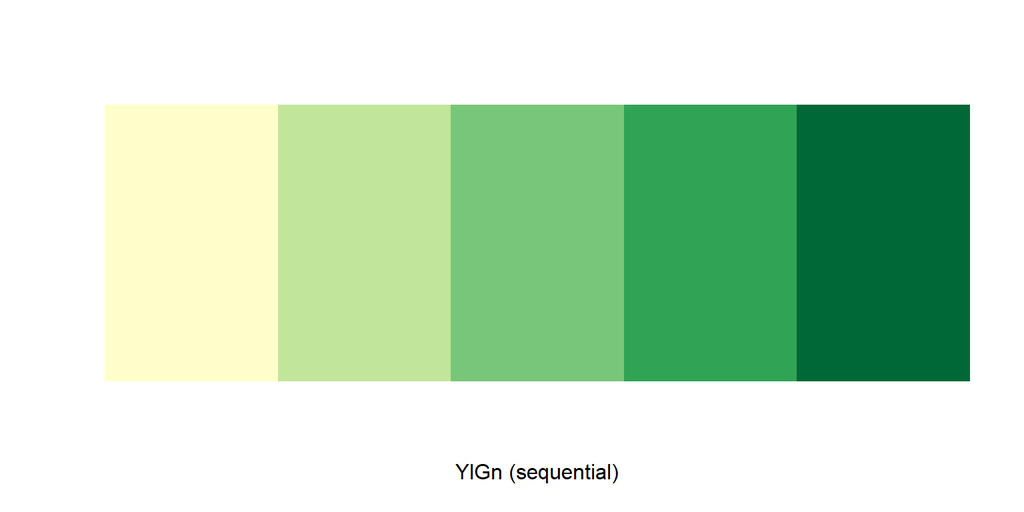

```r
myPalette <- brewer.pal(5, "YlGn")

display.brewer.pal(5, "YlGn")
```

# Ein erstes Beispiel

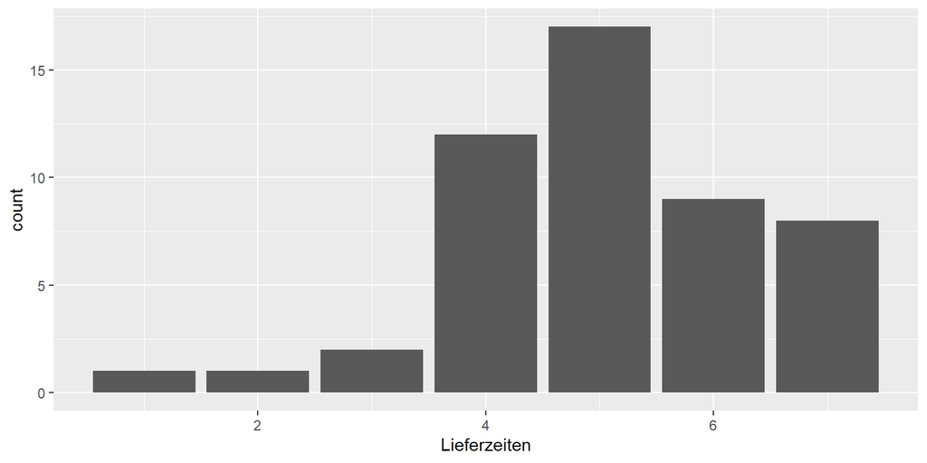

```r
ggplot(liefer) +
    geom_bar(mapping=aes(x=Lieferzeiten))
```

*ggplot* geht davon aus, dass die Daten im *wide*-Format vorliegen. Das bedeutet, dass jede Zeile ein Individuum beschreibt, mit den Merkmalen als Spalte. Dies ist in unserem kleinen Beispielen der Lieferzeiten der Fall, so dass wir *ggplot* direkt anwenden können.

# Vorbereitungen

```r
bars <-ggplot(liefer) +
           geom_bar(mapping=aes(x=Lieferzeiten),
                    fill=myPalette[3])
```

Wir können eine mit *ggplot* dargestellte Grafik abspeichern und weitere Features hinzufügen. Das bereiten wir jetzt vor und speichern auf der Variable *bars*.

# Farben verwenden

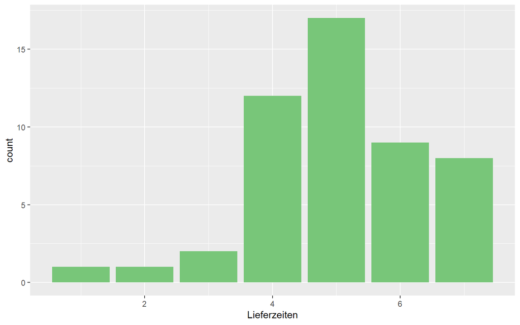

```r
bars
```

Wir haben in der Grafik das Attribut *fill* verwendet und damit die Füllfarbe der Balken verändert.

# Formatierung der x-Achse

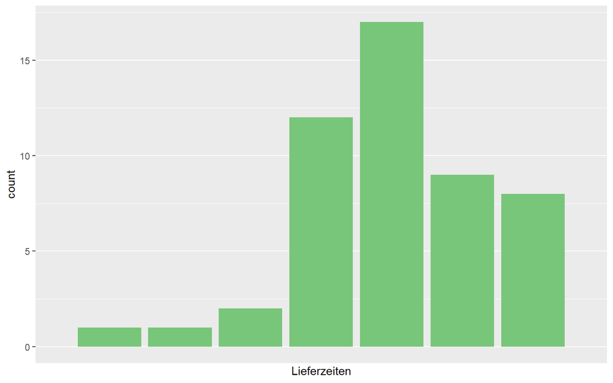

```r
bars + scale_x_discrete(breaks=seq(1,7))
```

Wir verwenden *scale_x_discrete* und formatieren damit die x-Achse.

# Beschriftungen

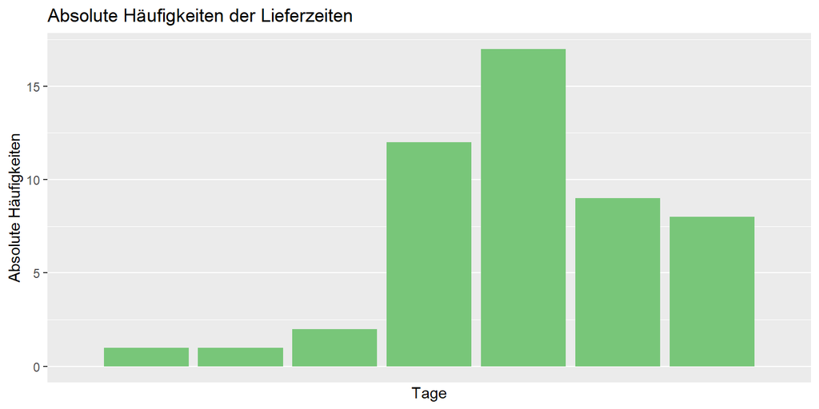

```r
bars +
  scale_x_discrete(breaks=seq(1,7)) +
  labs(
    title="Absolute Häufigkeiten der Lieferzeiten",
    x="Tage",
    y="Absolute Häufigkeiten"
  )
```

# Relative Häufigkeiten mit *y = after_stat(prop)*

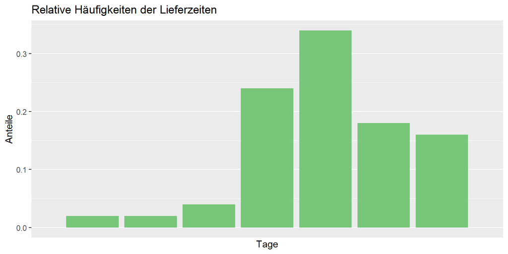

```r
ggplot(liefer) +
  geom_bar(mapping=aes(x = Lieferzeiten,
                       y = after_stat(prop)),
           fill=myPalette[3]) +
  scale_x_discrete(breaks= seq(1, 7)) +
  labs(
    title="Relative Häufigkeiten der Lieferzeiten",
    x="Tage",
    y="Anteile"
  )
```

# Vertikale und horizontale Ausgaben

```r
barVert <- ggplot(liefer) +
  geom_bar(mapping=aes(x = Lieferzeiten,
                       y = after_stat(prop)),
           fill=myPalette[3]) +
  scale_x_discrete(breaks=seq(1,7)) +
  labs(
    title="Relative Häufigkeiten der Lieferzeiten",
    x="Tage",
    y="Anteile"
  ) +
  coord_flip()
```

Wir können mit *coord_flip()* die Achsen vertauschen!

# Vertikales Balkendiagramm

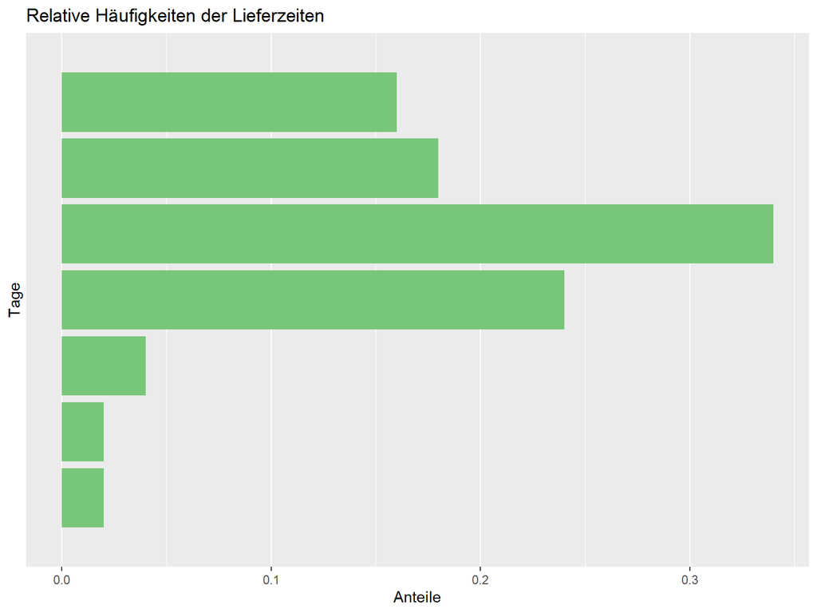

```r
barVert
```

Vertikale und horizontale Ausgaben erzeugen wir mit *coord_flip()*.

# Box-Plots

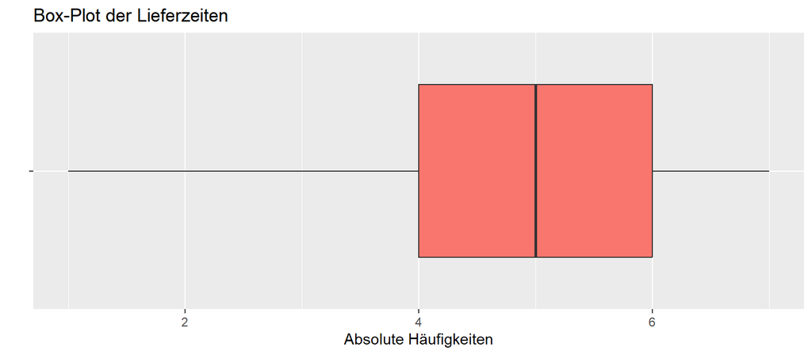

```r
ggplot(liefer)  +
  geom_boxplot(mapping=aes(x  ="",
                           y = Lieferzeiten,
                           fill = myPalette[2])) +
  labs(
    title="Box-Plot der Lieferzeiten",
    x="",
    y="Absolute Häufigkeiten"
  ) +
  coord_flip() +
  theme(legend.position = "none")
```

# Empirische Verteilungsfunktionen mit *stat_ecdf*

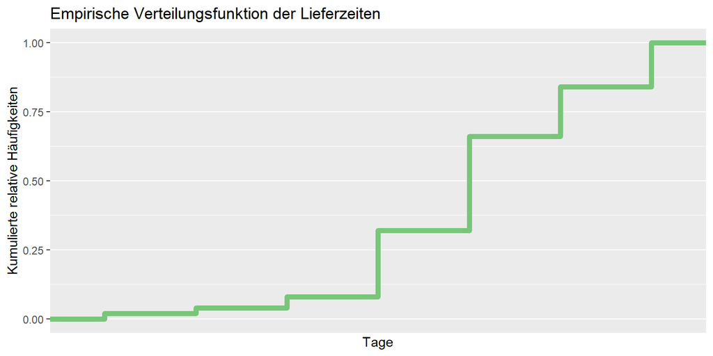

```r
ggplot(liefer, aes(x = Lieferzeiten)) +
  stat_ecdf(geom = "step", pad=TRUE,
            color = myPalette[3],
            linewidth = 2) +
  scale_x_discrete(breaks=seq(1,7)) +
  labs(
    title="Empirische Verteilungsfunktion der Lieferzeiten",
    x="Tage",
    y="Kumulierte relative Häufigkeiten"
  )
```

# Der Datensatz Körpergröße

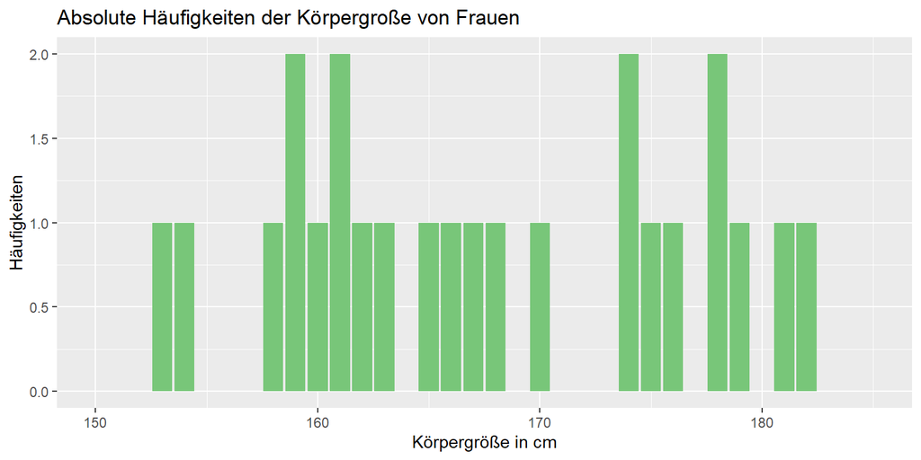

```r
ggplot(frauen)  +
  geom_bar(mapping=aes(x=Koerpergroesse), fill=myPalette[3]) +
  scale_x_continuous(limits=c(150.0, 185.0)) +
  labs(
    title="Absolute Häufigkeiten der Körpergroße von Frauen",
    x="Körpergröße in cm",
    y="Häufigkeiten"
  )
```

# Histogramme

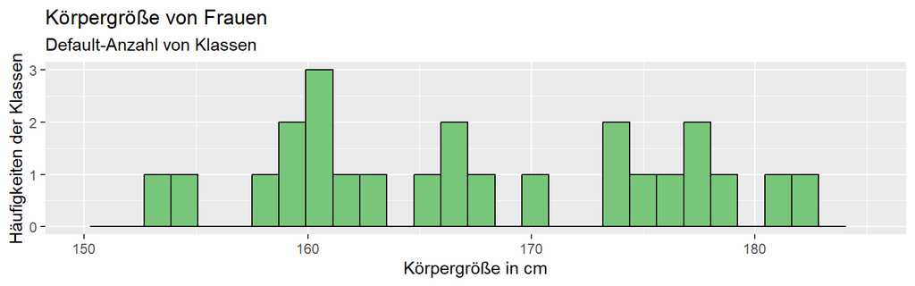

```r
ggplot(frauen) +
  geom_histogram(mapping=aes(x=Koerpergroesse), closed="left",
          fill=myPalette[3], color="black") +
  scale_x_continuous(limits=c(150.0, 185.0)) +
  labs(
    title="Körpergröße von Frauen",
    subtitle="Default-Anzahl von Klassen",
    x="Körpergröße in cm",
    y="Häufigkeiten der Klassen"
  )
```

# Bessere Wahl der Klassenbreite durch *breaks*

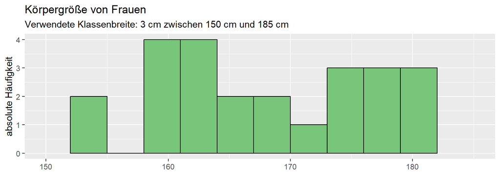

```r
ggplot(frauen) +
  geom_histogram(mapping=aes(x=Koerpergroesse),
                closed="left",
          breaks=seq(152.0, 182.0, 3.0),
          fill=myPalette[3], color="black") +
  scale_x_continuous(limits=c(150.0, 185.0)) +
  labs(
    title="Körpergröße von Frauen",
    subtitle="Verwendete Klassenbreite: 3 cm zwischen 150 cm und 185 cm",
    x="",
    y="absolute Häufigkeit"
  )
```

# Streuungsdiagramme

Wir verwenden den Datensatz *wassergehalt*:

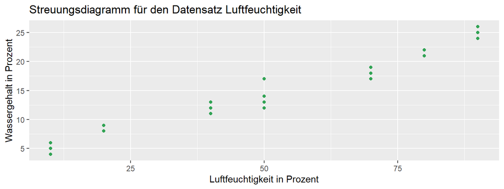

```r
ggplot(wassergehalt) +
  geom_point(mapping=aes(x = Luftfeuchtigkeit,
                         y = Wassergehalt),
             color=myPalette[4]) +
  labs(
    title="Streuungsdiagramm für den Datensatz Luftfeuchtigkeit",
    x="Luftfeuchtigkeit in Prozent",
    y="Wassergehalt in Prozent"
  )
```

# Ein Streuungsdiagramm für den Datensatz mpg

Im folgenden Beispiel verwenden wir den Datensatz *mpg*, der in R enthalten ist. Wir verwenden ein diskretes Merkmal und färben die Marker im Streuungsdiagramm.

Auf die x-Achse legen wir den Verbrauch in der Stadt auf der Spalte *cty*, auf der y-Achse finden wir den Verbrauch auf dem Highway aus der Spalte *hwy*. Die Anzahl der Zylinder in *cyl* verwenden wir für das Färben der marker.

# Ein Streuungsdiagramm mit Legende

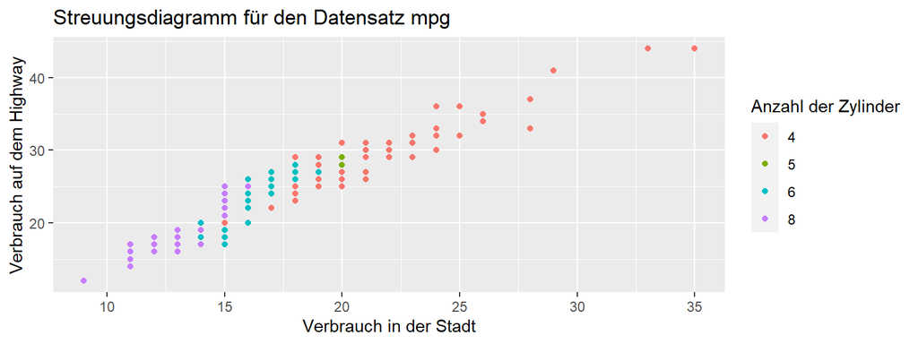

```r
ggplot(mpg) +
  geom_point(mapping=aes(x=cty,
                         y=hwy,
                         color=factor(cyl))) +
  labs(
    title="Streuungsdiagramm für den Datensatz mpg",
    x="Verbrauch in der Stadt",
    y="Verbrauch auf dem Highway",
    color="Anzahl der Zylinder"
  )
```

# Abspeichern von Abbildungen

[figure not shown]

```r
ggsave(filename="saveExample.png",
       plot=last_plot(),
       device="png",
       path="../images/",
       width=16, height=9, units="cm")
```

# Unklarheiten? Fragen? Bemerkungen?

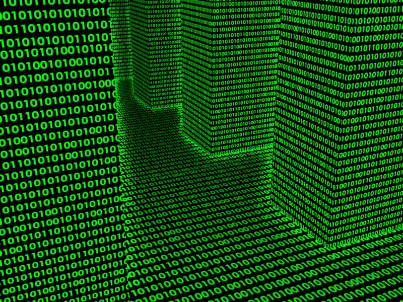

# Literaturverzeichnis

Wilkinson, Leland. 2005. *The Grammar of Graphics*. 2. ed. Springer.